# Replicating Owen (2019) on UK All-Weather Flat handicaps, 2006–2015

A conditional-logit model of race outcomes

Author

Patrick Gillen

Published

June 6, 2026

Abstract

We replicate the conditional-logit win model of Alun Owen (Owen 2019) on a different dataset: UK All-Weather (AW) Flat handicaps run at Kempton, Lingfield, Southwell and Wolverhampton between 2006-01-01 and 2015-10-14, restricted to Class 2–5. The feature set, model specification and diagnostic suite are kept as close to Owen’s as the data allow, and the fit is contrasted with Owen’s Table 3 (UK Turf Flat, 2014–2016). Calibration and the two probability-scoring rules he reports are evaluated out-of-sample on the held-out 30% of races. Coefficient signs largely agree with Owen’s; magnitudes drift in places consistent with the AW / Turf surface difference. The scoring picture is less encouraging than Owen’s: on this AW subset, the fitted model trails the market on both rules across most of the threshold range. One small design choice we own is that history-based features are built from each AW horse’s full cross-surface career, not its AW-only record; Section 2 sets out the empirical motivation. Other than that, the feature set, model specification and diagnostic suite are kept as close to Owen’s as the data allow. We see this work as a starting point: the second paper in this series will add features *and* move to the exploded conditional logit so the full finishing order, not just the win, contributes to the fit; the third will switch the model entirely, to a Plackett–Luce R² tree.

*Revised 2026-07-03.*[^1]

# 1 Introduction

Modelling the outcome of a horse race is a long-running problem in applied statistics and a useful proving ground for discrete-choice methods more generally. Owen (2019) fits a conditional-logit win model to UK Turf Flat racing over 2014–2016 and reports both the parameter estimates (his Table 3) and a small suite of probabilistic diagnostics: a calibration plot (his Figure 7) and two scoring rules (his Figure 8). Owen’s headline finding is that the model and the betting market track each other closely on calibration, with the market modestly sharper on the scoring rules.

This paper repeats that exercise on a different subset of the British racing programme: handicap races on the four UK All-Weather (AW) courses — Kempton, Lingfield, Southwell and Wolverhampton — between 1 January 2006 and 14 October 2015, restricted to Class 2–5 (see Section 2 for why these bounds). The intent is replication, not novelty: we use the same feature set as Owen, the same model specification (a no-intercept conditional logit fitted with {mlogit}), and the same diagnostic plots. The one design choice we own is to build history-based features from each AW horse’s full cross-surface career rather than its AW-only record; Section 2 motivates that empirically.

We make no claim to extend or to better Owen’s work in this paper. The contribution, such as it is, is a careful translation of his recipe onto a population that differs from his in three ways at once: surface (AW vs Turf), window length (a decade vs three years) and race-type scope (we restrict to Class 2–5 handicaps, and the two scopes are not directly comparable along this axis). Two follow-up papers, signposted in passing throughout but not attempted here, will pick up where this one stops. The second adds features to the same backbone *and* fits it via the exploded conditional logit, so the full finishing order — not just the win — contributes to the likelihood. The third moves off the conditional-logit framework altogether, to a Plackett–Luce R² tree.

The paper is organised as follows. Section 2 describes the data and the race-selection rules, including a digression on why we have built features from each horse’s full career history rather than its AW record alone. Section 3 walks through the same kind of feature-by- feature exploratory plots Owen reports. Section 4 presents the fitted model alongside Owen’s Table 3, then evaluates calibration and the two probability-scoring rules on held-out test races. Section 6, an appendix, derives the conditional logit from the binary case.

# 2 Data and race selection

## 2.1 Source: the Smartform database

All race data come from the Smartform MySQL database. The two tables we draw on are `historic_races`, which holds one row per race, and `historic_runners`, which holds one row per declared runner per race. A horse is identified by its `runner_id`, which is stable across races and surfaces, so the same horse’s runs at AW and turf courses can be linked. The full extraction is driven from `sql/qualifying_races.sql`, `sql/runners_for_races.sql` and `sql/horse_full_history.sql`; pull-and-clean functions in `R/` lift the resulting tibbles[^2] into the `targets` pipeline.

## 2.2 The British class system, and why we begin in 2006

British flat racing is organised along two independent axes. The first is a quality tier: Group races, then Listed races (together making up Class 1), then Classes 2–7 in decreasing order of prize money and minimum ability. The second is the method by which weights are assigned: a *handicap* allocates each horse a weight set by the BHA Handicapper from its Official Rating, while a *conditions* race uses the race’s own eligibility rules to level the field (most commonly weight-for-age in maidens and novices).

The class scheme used today, with Classes 1–7, was introduced on 1 January 2006. Prior to that, the data carry a two-digit class code (11, 42, 53, 64, …) whose meaning is not directly comparable. Rather than recode pre-2006 entries, we simply restrict the window to 1 January 2006 onwards. The upper end of our window, 14 October 2015, is the most recent date for which the database extract we work with is current.

Within Classes 2–7, the choice of which tier of race to model and whether to restrict to handicaps or conditions races has a real bearing on what the model can learn. Class 1 is qualitatively different — its races are conditions-only and run between the best horses in training, with the assigned-weights mechanism that Classes 2–7 share entirely absent. The conditions-versus-handicap distinction within Classes 2–7 also matters: handicap weights are set by the same BHA Handicapper, against the same Official Rating, across all four AW courses and all classes from 2–7, so the mechanism by which a horse’s *ability* gets translated into an *assigned weight* is consistent throughout the scope we model.

We restrict to Class 2–5 handicaps on two grounds. First, Class 2–5 handicaps account for the overwhelming majority of races at the four AW courses we model — Classes 6–7 are sparse on the all-weather, and Class 1 races on these courses are negligible. Second, restricting to handicaps means every race in our population shares the same weight-assignment mechanism.

## 2.3 All-Weather course scope

- **Chelmsford City** opened in January 2015. Inside our window it contributes only nine months of racing — not enough for the career-history feature build to behave consistently with the four longer-established courses.
- **Newcastle’s** AW track came on stream in May 2016, after our window ends. There is no Newcastle AW history in scope.
- **Dundalk** is an Irish course, outside the UK scope.

We do *not* control for surface or course in the headline model specification in Section 4, because Owen does not control for them either: in his Turf Flat scope, almost all races share a single surface family. The fact that our four courses span two surfaces (Polytrack and Fibresand) is one of several differences from Owen that we flag and absorb into the residual variation rather than attempt to model explicitly. Adding a surface or course interaction is one of the candidate features for paper 2, which extends the feature set and refits with the exploded conditional logit.

**NoteThe AW data scope, in one place**

- **Source**: Smartform `historic_races` ⋈ `historic_runners`.
- **Race type**: All Weather Flat, filtered on `race_type` rather than the unreliable `all_weather` flag (the flag drops ~2,500 legitimate AW races at our four courses).
- **Courses**: Kempton, Lingfield, Southwell, Wolverhampton.
- **Class**: 2–5.
- **Race kind**: handicaps only (`handicap = 1`); non-maiden.
- **Date window**: 2006-01-01 to 2015-10-14.
- **Field size**: 4–16 declared runners; re-checked as 4+ *actual* starters after Non-Runners are removed.
- **Winner**: `coalesce(amended_position, finish_position) == 1`, to pick up the seven post-disqualification promotions in scope.
- **Dead heats**: 35 races with two `won = 1` rows are dropped, as {mlogit} cannot fit a choice set with two chosen alternatives.

After these filters, the SQL produces 7,507 candidate races. The R-level cuts (post-Non-Runner field-size and dead-heat removal) take this down to **7,441 qualifying races** containing **66,770 runner-race observations**, drawn from **17,376 distinct horses**.

Headline counts for the qualifying AW population.

| Quantity | Value |
| --- | --- |
| Qualifying races | 7,441 |
| Runner-race observations | 66,770 |
| Distinct horses | 17,376 |
| Date range (first race) | 2006-01-01 |
| Date range (last race) | 2015-10-14 |

The class distribution of the qualifying races is consistent with the broader picture that AW racing is concentrated in mid-tier handicaps:

Number of qualifying races by Class.

| Class | Races |
| --- | --- |
| 2 | 405 |
| 3 | 520 |
| 4 | 2365 |
| 5 | 4151 |

## 2.4 Train / test split

For the modelling in Section 4 we split the qualifying races into a training set and a held-out test set chronologically, by race date, in a 70 / 30 ratio. The cutoff date is **2012-12-30**, identified by sorting races by `meeting_date` and locating the 70th percentile; we freeze the date so the split is reproducible against an exact calendar boundary irrespective of upstream changes. The split is on race date, so every runner in a race stays together in one set — no within-race information leaks across the boundary.

Chronological 70/30 train/test split. Cutoff: 2012-12-30 inclusive in training.

| Set | Races | Runner-rows |
| --- | --- | --- |
| Training | 5,209 | 47,893 |
| Test | 2,232 | 18,877 |

## 2.5 Why we use full cross-surface career history

A choice we make early is whether to compute history-based features (days since last run, prior finishing positions, sire and trainer strike rates) from each horse’s AW races alone or from its full career across all surfaces and courses. We do the latter; this subsection sets out the empirical motivation. It is a digression from the main thread but worth dwelling on because it affects every history-based feature in Section 3 and Section 4.

### 2.5.1 How much of each horse’s career is spent at AW courses?

The four AW venues account for a minority of most horses’ career starts.

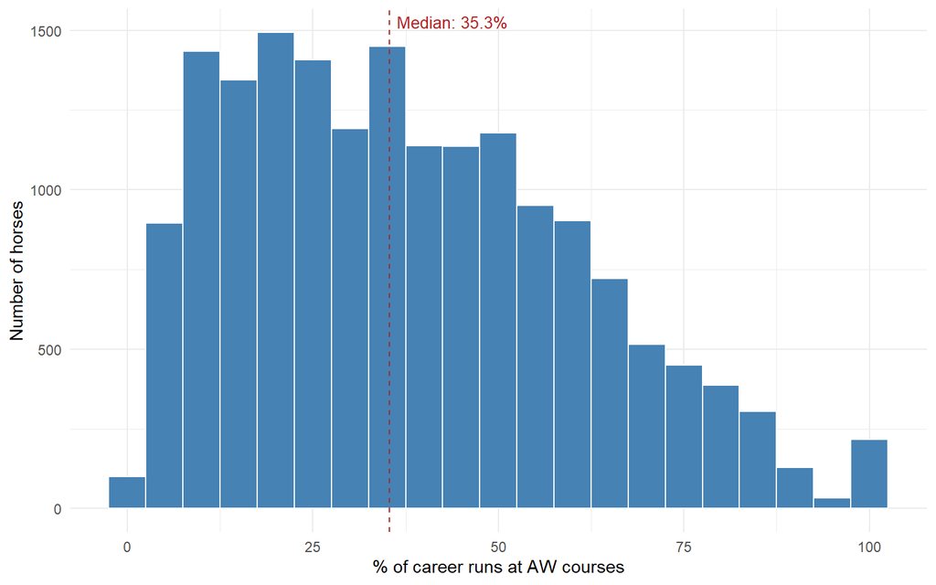

Figure 1: What share of career races were at AW courses? Histogram over the qualifying horse population. The dashed line is the median.

The median qualifying horse runs only 35.3% of its career at AW courses. The distribution is broad — some horses are pure AW specialists (100%) while others run at AW only as occasional turf-career interludes (the left tail below 10%). A meaningful fraction of our population has barely any AW history at all at the moment we observe them in an AW race.

### 2.5.2 Where else do AW horses run?

The four AW courses — and Wolverhampton in particular — dominate the picture by volume, which is the mechanical consequence of selecting the population on AW participation in the first place. Beyond the AW set, runs are spread across more than fifty other courses nationwide; the population has run more or less everywhere in Britain.

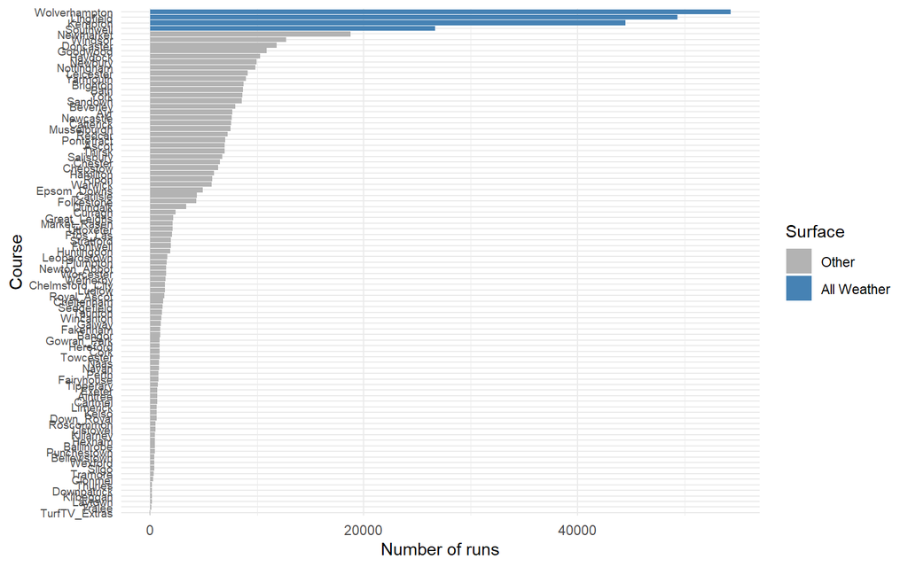

Figure 2: Total runs at each course across the qualifying horse population. AW courses highlighted in blue.

### 2.5.3 Would AW-only daysLTO mislead us?

The single most testable consequence of restricting to AW history is that `daysLTO` — days since the horse’s last race — would be computed against a thinner stream of prior runs. For each qualifying runner-race we computed `daysLTO` two ways: using only prior AW races, and using all prior races regardless of surface.

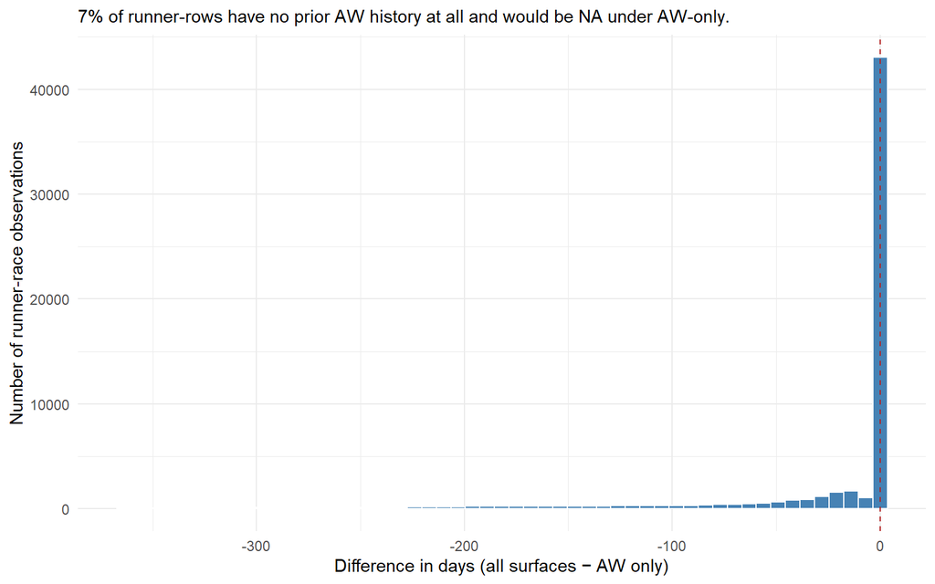

Figure 3: Difference in days since last run when AW-only history is replaced by full cross-surface history, per qualifying runner-race. Negative values mean cross-surface history finds a more recent run that AW-only misses.

The spike at zero is large — for most observations the most recent prior run was an AW race and the two methods agree. But the left tail is material, and 7% of runner-rows have no prior AW race at all, so an AW-only `daysLTO` cannot be defined for them.

We therefore build every history-based feature in this paper from each horse’s full cross-surface career history. Restricting to AW history would discard real form information for most of the population and would produce missing values at a rate that would distort the model fit.

# 3 Exploratory analysis

This section reproduces, on the AW population, the kind of feature-by-feature exploration that motivates Owen’s choice of predictors. For each candidate predictor we plot empirical win rate against the feature, with bins chosen to give enough mass per bar that the per-bin standard error remains informative. The dashed reference line on each plot is the headline win rate over the data shown.

The headline win rate over the full qualifying population is the mechanical consequence of average field size: with field sizes between 4 and 16 runners and exactly one winner per race, the average win rate per runner-row is the reciprocal of the mean field size.

Headline counts on the joined features tibble (training + test).

[output not shown]

We work off the joined `features` tibble produced by the pipeline. It carries 13 modelling columns: `age_diff` (Owen’s symmetric- distance age encoding around 3), `sireSR` and `trainerSR` (cumulative strike rates with strict no-leakage), `days_LTO_log = log(days_LTO + 1)`, the prior-finish lags `position1` / `position2` / `position3` (each encoded as 0–4 with 0 meaning “no prior run, or finished worse than 4th”), and the six binary tack / sex indicators `entire`, `gelding`, `blinkers`, `cheekpieces`, `visor`, `tonguetie`.

## 3.1 Age

Table 1: Win rate by raw age (years), with bin-level standard errors.

| feature | feature_bin | n | n_wins | win_rate | se |
| --- | --- | --- | --- | --- | --- |
| age | 2 | 3773 | 458 | 0.1214 | 0.0053 |
| age | 3 | 18090 | 2246 | 0.1242 | 0.0025 |
| age | 4 | 15853 | 1932 | 0.1219 | 0.0026 |
| age | 5 | 11144 | 1236 | 0.1109 | 0.0030 |
| age | 6 | 7534 | 763 | 0.1013 | 0.0035 |
| age | 7 | 5029 | 441 | 0.0877 | 0.0040 |
| age | 8 | 2969 | 209 | 0.0704 | 0.0047 |
| age | 9 | 1478 | 103 | 0.0697 | 0.0066 |
| age | 10 | 555 | 27 | 0.0486 | 0.0091 |
| age | 11 | 223 | 16 | 0.0717 | 0.0173 |
| age | 12 | 96 | 10 | 0.1042 | 0.0312 |
| age | 13 | 22 | 0 | NA | NA |
| age | 14 | 4 | 0 | NA | NA |

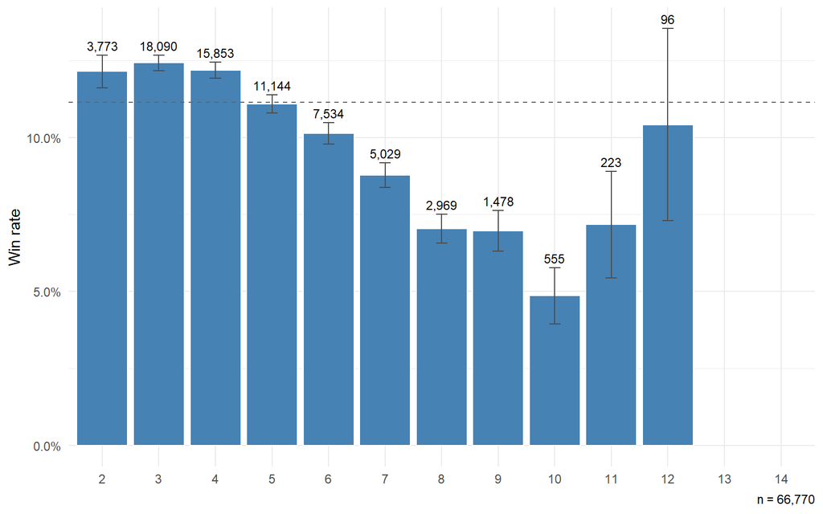

Figure 4: Win rate by raw age (years).

The win-rate-by-age curve on AW data peaks early and declines as the horses get older. Owen (Owen 2019) captures the age effect with a symmetric-distance encoding, `age_diff = |age - 4.5|`, taking 4.5 as the peak from published evidence on thoroughbred ageing curves.

For AW we depart in two small ways. First, the empirical AW peak sits noticeably younger than 4.5 — closer to age 3 — reflecting that AW campaigns are disproportionately run by faster-maturing horses; we therefore take the peak as 3. Second, the AW window carries very few starters above age 8, so a raw absolute distance extrapolates the effect into thinly-supported old-age bins; we cap the unsigned offset at 5, holding `age_diff` flat above age 8. Concretely the regression in Section 4 uses `age_diff = pmin(|age - 3|, 5)`.

## 3.2 Days since last race

We bin `days_LTO` into intervals matching the rest-effect ranges Owen discusses. NA values become a `(missing)` bin, which here captures first-time runners with no prior race to count days from.

Table 2: Win rate by days since last race, with rest-effect bins.

| feature | feature_bin | n | n_wins | win_rate | se |
| --- | --- | --- | --- | --- | --- |
| days_LTO | [0,7) | 3876 | 591 | 0.1525 | 0.0058 |
| days_LTO | [7,14) | 14609 | 1762 | 0.1206 | 0.0027 |
| days_LTO | [14,30) | 26766 | 3015 | 0.1126 | 0.0019 |
| days_LTO | [30,60) | 10989 | 1140 | 0.1037 | 0.0029 |
| days_LTO | [60,90) | 2724 | 264 | 0.0969 | 0.0057 |
| days_LTO | [90,180) | 4580 | 402 | 0.0878 | 0.0042 |
| days_LTO | [180,365) | 2758 | 239 | 0.0867 | 0.0054 |
| days_LTO | [365,Inf] | 466 | 28 | 0.0601 | 0.0110 |
| days_LTO | (missing) | 2 | 0 | NA | NA |

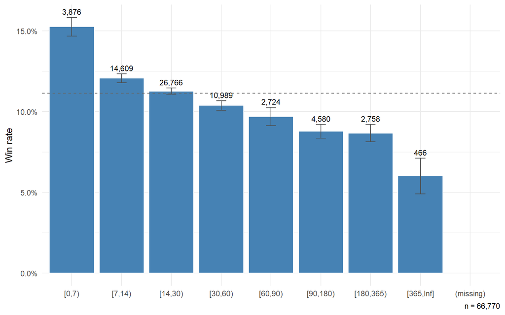

Figure 5: Win rate by days since last race, on rest-effect bins.

Win rate softens as days since last race grows, with the long-tail bins (180+ days) sitting noticeably below the headline. Owen reports a small negative coefficient on raw `daysLTO` (~ −0.004). The log-transformed version we use (`days_LTO_log = log(days_LTO + 1)`) re-shapes the same effect on a more even scale; the empirical relationship visible here is monotonically (and mildly) decreasing.

## 3.3 Binary tack and sex indicators

The six binary features are a sex pair (`entire`, `gelding`) and four tack indicators (`blinkers`, `cheekpieces`, `visor`, `tonguetie`). They are aliased on each other in the obvious way — fillies and mares are neither `entire` nor `gelding`, and a runner without a piece of tack has the corresponding indicator 0.

Table 3: Win rate by binary feature: 0 / 1 split per indicator.

| feature | feature_bin | n | n_wins | win_rate | se |
| --- | --- | --- | --- | --- | --- |
| entire | 0 | 59516 | 6327 | 0.1063 | 0.0013 |
| entire | 1 | 7254 | 1114 | 0.1536 | 0.0042 |
| gelding | 0 | 23306 | 2778 | 0.1192 | 0.0021 |
| gelding | 1 | 43464 | 4663 | 0.1073 | 0.0015 |
| blinkers | 0 | 59899 | 6711 | 0.1120 | 0.0013 |
| blinkers | 1 | 6871 | 730 | 0.1062 | 0.0037 |
| cheekpieces | 0 | 60489 | 6859 | 0.1134 | 0.0013 |
| cheekpieces | 1 | 6281 | 582 | 0.0927 | 0.0037 |
| visor | 0 | 62827 | 7005 | 0.1115 | 0.0013 |
| visor | 1 | 3943 | 436 | 0.1106 | 0.0050 |
| tonguetie | 0 | 62339 | 7012 | 0.1125 | 0.0013 |
| tonguetie | 1 | 4431 | 429 | 0.0968 | 0.0044 |

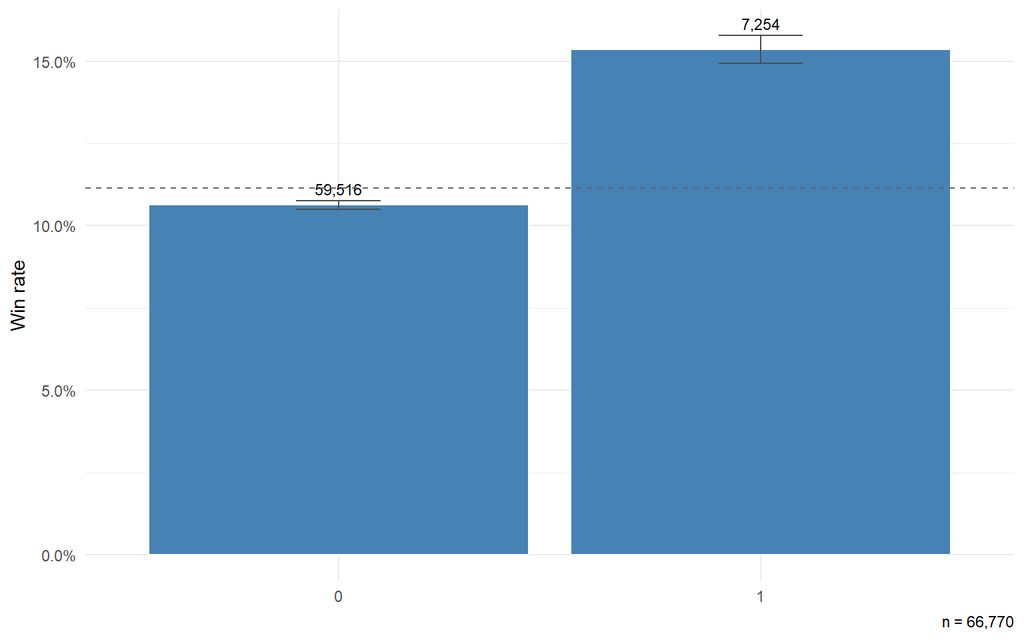

Figure 6: Win rate by entire

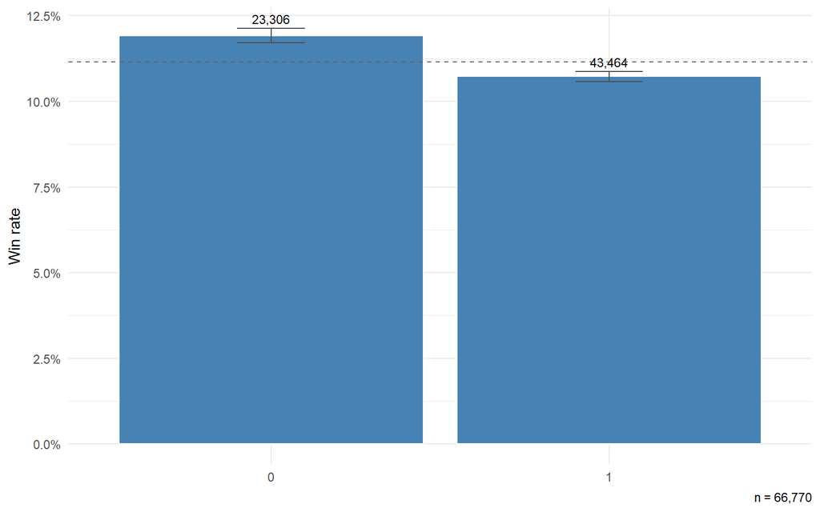

Figure 7: Win rate by gelding

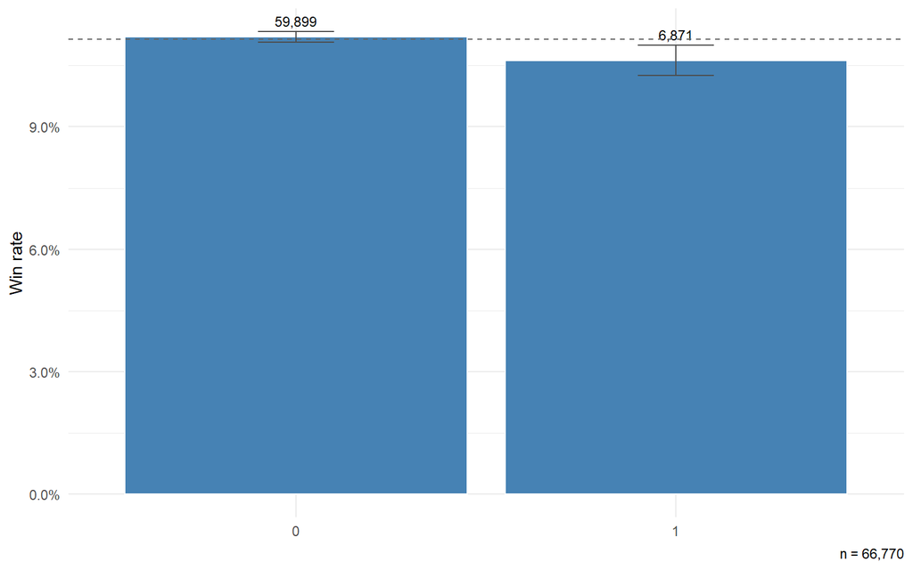

Figure 8: Win rate by blinkers

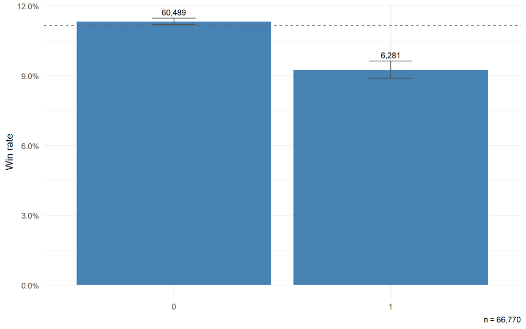

Figure 9: Win rate by cheekpieces

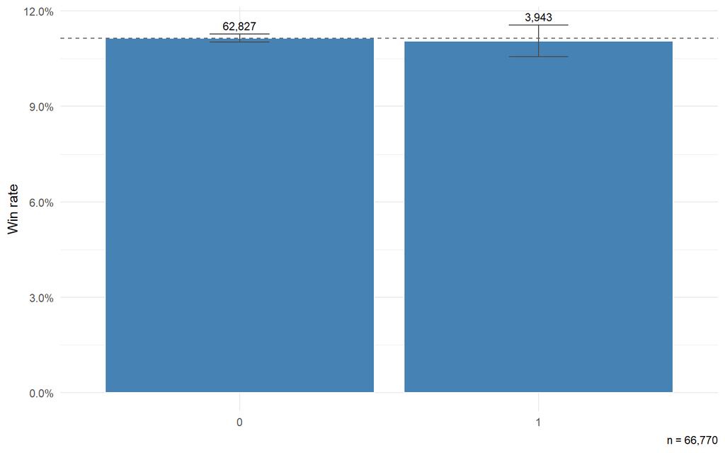

Figure 10: Win rate by visor

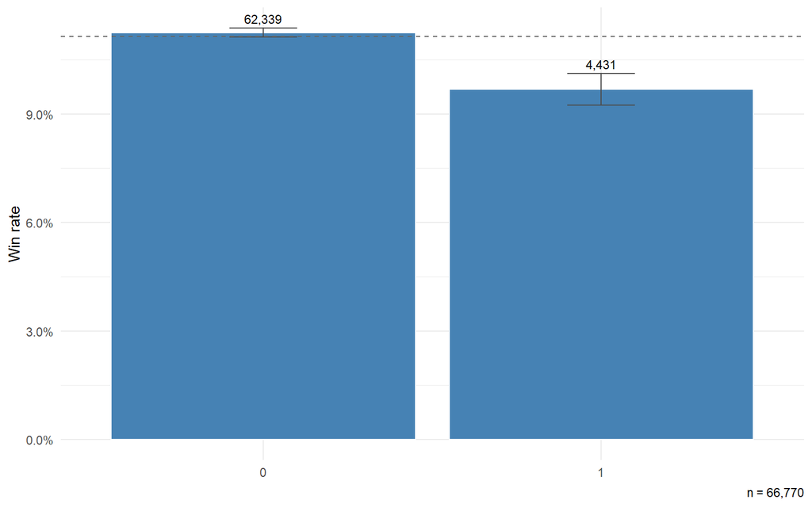

Figure 11: Win rate by tonguetie

## 3.4 Prior finishing positions

Owen’s `position1`, `position2`, `position3` encode the horse’s finishing position in its most recent, second-most-recent and third-most-recent prior races. Each is an integer in {0, 1, 2, 3, 4}, where the level corresponds to the actual finishing position and 0 means “no prior run available, or finished worse than 4th”.

Table 4: Win rate by prior-finish lag (0–4 levels).

| feature | feature_bin | n | n_wins | win_rate | se |
| --- | --- | --- | --- | --- | --- |
| position1 | 0 | 34372 | 2653 | 0.0772 | 0.0014 |
| position1 | 1 | 10050 | 1916 | 0.1906 | 0.0039 |
| position1 | 2 | 7770 | 1156 | 0.1488 | 0.0040 |
| position1 | 3 | 7481 | 984 | 0.1315 | 0.0039 |
| position1 | 4 | 7097 | 732 | 0.1031 | 0.0036 |
| position2 | 0 | 33855 | 3099 | 0.0915 | 0.0016 |
| position2 | 1 | 9691 | 1466 | 0.1513 | 0.0036 |
| position2 | 2 | 8292 | 1115 | 0.1345 | 0.0037 |
| position2 | 3 | 7822 | 955 | 0.1221 | 0.0037 |
| position2 | 4 | 7110 | 806 | 0.1134 | 0.0038 |
| position3 | 0 | 34712 | 3538 | 0.1019 | 0.0016 |
| position3 | 1 | 9163 | 1142 | 0.1246 | 0.0035 |
| position3 | 2 | 8234 | 1005 | 0.1221 | 0.0036 |
| position3 | 3 | 7587 | 921 | 0.1214 | 0.0037 |
| position3 | 4 | 7074 | 835 | 0.1180 | 0.0038 |

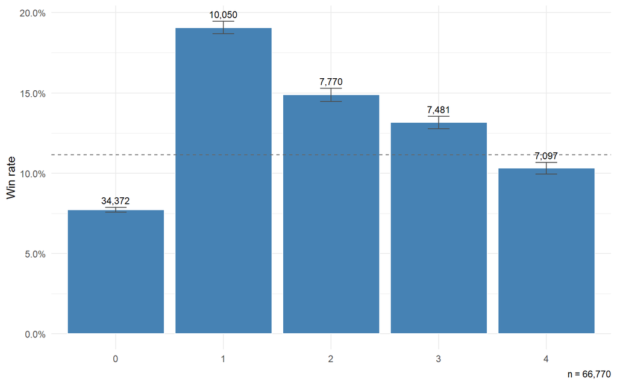

Figure 12: Win rate by position1 (most recent prior finish)

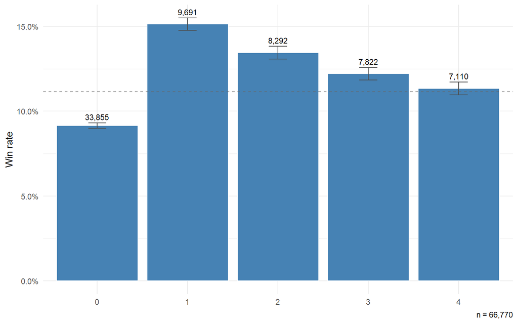

Figure 13: Win rate by position2 (second-most-recent prior finish)

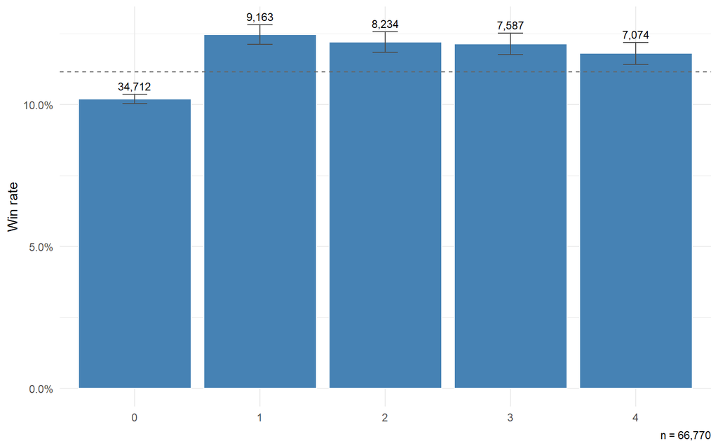

Figure 14: Win rate by position3 (third-most-recent prior finish)

The pattern Owen reports is that the win-rate effect is largest for `position1` and weakens as we look further back: `position1` levels 1–4 are positive and declining; `position2` levels 1–4 are smaller and also declining; `position3` levels are dropped as non-significant. The AW plots are consistent with this picture — the lift from being a recent winner is larger than the lift from being a winner-before-last, and the third-from-last race’s positional bin gaps are small relative to their standard errors.

## 3.5 Sire and trainer strike rates

`sireSR` and `trainerSR` are cumulative win rates over all races strictly before the runner’s race date. They are continuous in $[0, 1]$ and uncapped; we bin them with breaks that give finer resolution at the low end — where most of the mass sits — and a long tail bin above 0.50.

Table 5: Win rate by sire strike rate, with finer bins at the low end.

| feature | feature_bin | n | n_wins | win_rate | se |
| --- | --- | --- | --- | --- | --- |
| sireSR | [0,0.05) | 1945 | 155 | 0.0797 | 0.0061 |
| sireSR | [0.05,0.1) | 31153 | 3124 | 0.1003 | 0.0017 |
| sireSR | [0.1,0.15) | 30028 | 3626 | 0.1208 | 0.0019 |
| sireSR | [0.15,0.2) | 3050 | 459 | 0.1505 | 0.0065 |
| sireSR | [0.2,0.3) | 403 | 49 | 0.1216 | 0.0163 |
| sireSR | [0.3,0.5) | 83 | 15 | 0.1807 | 0.0422 |
| sireSR | [0.5,1] | 43 | 9 | 0.2093 | 0.0620 |
| sireSR | (missing) | 65 | 4 | 0.0615 | 0.0298 |

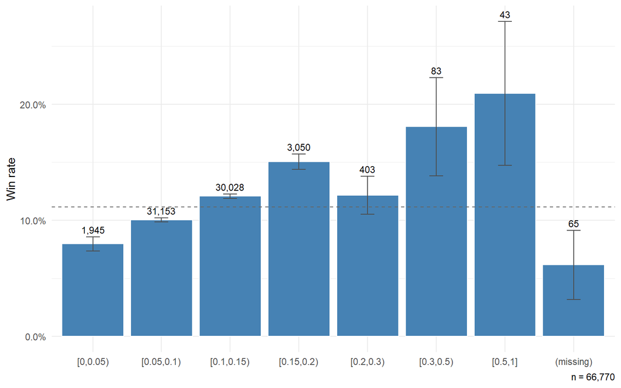

Figure 15: Win rate by sire strike rate.

Table 6: Win rate by trainer strike rate.

| feature | feature_bin | n | n_wins | win_rate | se |
| --- | --- | --- | --- | --- | --- |
| trainerSR | [0,0.05) | 3731 | 229 | 0.0614 | 0.0039 |
| trainerSR | [0.05,0.1) | 35566 | 3370 | 0.0948 | 0.0016 |
| trainerSR | [0.1,0.15) | 21414 | 2795 | 0.1305 | 0.0023 |
| trainerSR | [0.15,0.2) | 4965 | 801 | 0.1613 | 0.0052 |
| trainerSR | [0.2,0.3) | 1007 | 231 | 0.2294 | 0.0132 |
| trainerSR | [0.3,0.5) | 41 | 7 | 0.1707 | 0.0588 |
| trainerSR | [0.5,1] | 17 | 3 | NA | NA |
| trainerSR | (missing) | 29 | 5 | NA | NA |

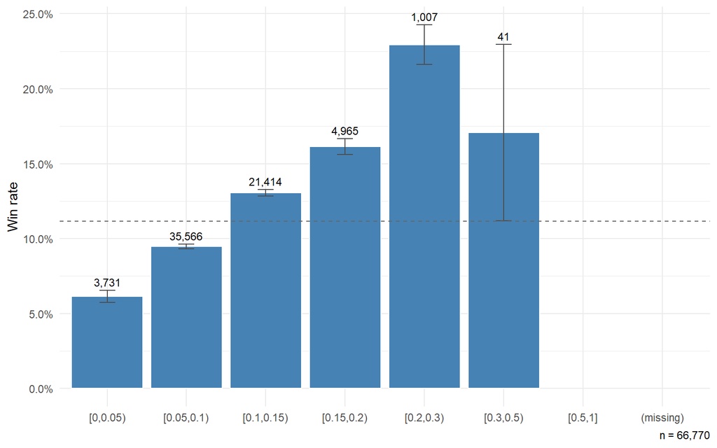

Figure 16: Win rate by trainer strike rate.

We take these patterns into Section 4 as motivation for the predictor set rather than as quantitative claims. The conditional- logit fit is the proper test of which features carry signal once the others are controlled for.

# 4 Model results

This section fits Owen’s conditional-logit win model on the AW training data, compares the resulting coefficients to those Owen reports in his Table 3 (Owen 2019), and then evaluates the model’s calibration and proper scoring on the held-out test races.

The recipe is deliberately the same as Owen’s. We fit the full 13-feature specification on the training subset, then — paralleling the editing step that yields Owen’s Table 3 — drop every term whose $p$-value exceeds 0.05 in the full fit and refit on the same data. The reduced fit is our headline; we treat it as the AW analogue of Owen’s Table 3, since Owen’s Table 3 is itself a reduced model.

The conditional-logit machinery — softmax over the runners in a race, no intercept, no race-specific covariates — is derived from first principles in Section 6. In R, the fit is produced by {mlogit}; the data is reshaped to {mlogit}’s long-form choice format with `chid.var = "race_id"` and `alt.var = "horse_ref"` (a per-race runner index in $\{1, \ldots, n_{\text{runners}}\}$) inside the pipeline target `mlogit_train_data`.

## 4.1 Specification

The full Owen specification fitted on the AW training races is

$$\begin{align*}
P(\text{horse } j \text{ wins race } i)
= \frac{\exp(z_{ij})}{\sum_{m} \exp(z_{im})},
\end{align*}$$

with

$$\begin{align*}
z_{ij} =
\beta_1 \,\text{age\_diff}_{ij}
&+ \beta_2 \,\text{sireSR}_{ij}
+ \beta_3 \,\text{trainerSR}_{ij}
+ \beta_4 \,\text{days\_LTO\_log}_{ij} \\
&+ \beta_5 \,\text{position1}_{ij}
+ \beta_6 \,\text{position2}_{ij}
+ \beta_7 \,\text{position3}_{ij} \\
&+ \beta_8 \,\text{entire}_{ij}
+ \beta_9 \,\text{gelding}_{ij}
+ \beta_{10}\,\text{cheekpieces}_{ij} \\
&+ \beta_{11}\,\text{blinkers}_{ij}
+ \beta_{12}\,\text{visor}_{ij}
+ \beta_{13}\,\text{tonguetie}_{ij}.
\end{align*}$$

The three lag-position terms enter as factor variables with five levels (0, 1, 2, 3, 4), so each contributes four estimated dummy coefficients to the fit and twelve in total.

There are two material divergences from Owen’s specification. First, we use $\log(1 + \text{daysLTO})$ rather than raw `daysLTO`; the substitution is a matter of better-conditioned numerical scaling across the larger dynamic range produced by horses with very long gaps between AW runs. Coefficient magnitudes on `days_LTO_log` and `daysLTO` are therefore not directly comparable, but signs and significance are. Second, we encode age as `pmin(|age - 3|, 5)` rather than Owen’s `|age - 4.5|`; the AW empirical peak sits closer to 3 than 4.5, and the cap at distance 5 prevents the effect from extrapolating into the thinly-supported old-age bins (Section 3).

## 4.2 The full fit and term-by-term significance

Table 7: Full Owen specification fitted on the AW training data.

| parameter | estimate | std.error | p.value | signif |
| --- | --- | --- | --- | --- |
| age_diff | -0.0903 | 0.0135 | 0.0000 | *** |
| sireSR | 2.3484 | 0.4117 | 0.0000 | *** |
| trainerSR | 5.0885 | 0.4011 | 0.0000 | *** |
| days_LTO_log | -0.1186 | 0.0174 | 0.0000 | *** |
| position11 | 0.7698 | 0.0414 | 0.0000 | *** |
| position12 | 0.5665 | 0.0465 | 0.0000 | *** |
| position13 | 0.4609 | 0.0489 | 0.0000 | *** |
| position14 | 0.2109 | 0.0540 | 0.0001 | *** |
| position21 | 0.3256 | 0.0431 | 0.0000 | *** |
| position22 | 0.2273 | 0.0466 | 0.0000 | *** |
| position23 | 0.1707 | 0.0492 | 0.0005 | *** |
| position24 | 0.1262 | 0.0520 | 0.0153 | * |
| position31 | 0.0767 | 0.0457 | 0.0935 | ns |
| position32 | 0.1011 | 0.0475 | 0.0332 | * |
| position33 | 0.1475 | 0.0485 | 0.0023 | ** |
| position34 | 0.0932 | 0.0509 | 0.0671 | ns |
| entire | 0.5455 | 0.0562 | 0.0000 | *** |
| gelding | 0.2791 | 0.0445 | 0.0000 | *** |
| cheekpieces | -0.2878 | 0.0610 | 0.0000 | *** |
| blinkers | -0.1329 | 0.0517 | 0.0102 | * |
| visor | -0.0566 | 0.0673 | 0.4003 | ns |
| tonguetie | -0.1623 | 0.0684 | 0.0176 | * |

Table 8: Aggregate fit statistics for the full specification.

| Statistic | Value |
| --- | --- |
| McFadden R² | 0.0532 |
| Null deviance | 22387.7 |
| Residual deviance | 21196.0 |
| Runner-rows (training) | 47,299 |
| Races (training) | 5,150 |

The runner-row and race counts here are slightly below the training-split counts reported in Section 2. We do not impute, and we do not drop individual runners; instead we drop the **whole race** if any of its runners has an NA in a modelling column. The race-level drop is the right granularity here because {mlogit} requires exactly one chosen alternative per choice set, and removing a single runner could leave a race with zero or two recorded winners. The NA cases are almost entirely a first-time-starter sire (no prior strike rate defined) or a debut trainer; the small reduction (1.13% of training races, 1.24% of runner-rows) is the residual cost of the strict-no-leakage rule on sire and trainer strike rates.

We follow Owen and drop any term whose every level has $p > 0.05$. For factor terms (the three `position` lags), a term is retained if *any* of its four dummy levels reaches significance.

**Dropped terms** (no level with $p < 0.05$ in the full fit): visor.

## 4.3 Reduced model (headline)

The reduced model is fitted on the same training data with the formula automatically constructed from the retained terms. This is the AW analogue of Owen’s Table 3; Table 9 sets it side-by-side with the values Owen reports.

Table 9: AW reduced model (training fit) vs Owen (2019) Table 3 (UK Turf Flat 2014–2016). Two rows are not directly comparable on absolute magnitude: `days_LTO_log` (AW uses log; Owen uses raw `daysLTO`), and `sireSR` / `trainerSR` (Owen appears to report on a percentage scale, our coefficients are on a proportion scale — divide AW by 100 for a like-for-like comparison; see text).

| Parameter | Owen est. | Owen SE | Owen p | AW est. | AW SE | AW sig. | AW − Owen | Note |
| --- | --- | --- | --- | --- | --- | --- | --- | --- |
| age_diff | -0.152 | 0.0313 | <0.001 | -0.0904 | 0.0135 | *** | 0.0616 | Same direction |
| sireSR | 0.048 | 0.0093 | <0.001 | 2.3551 | 0.4116 | *** | 2.3071 | Same direction |
| trainerSR | 0.051 | 0.0093 | <0.001 | 5.0939 | 0.4011 | *** | 5.0429 | Same direction |
| days_LTO_log | -0.004 | 0.0018 | 0.021 | -0.1175 | 0.0174 | *** | -0.1135 | Same direction (AW: log(1 + daysLTO); Owen: raw daysLTO; scales differ) |
| position11 | 0.607 | 0.0918 | <0.001 | 0.7701 | 0.0414 | *** | 0.1631 | Same direction |
| position12 | 0.329 | 0.1003 | <0.001 | 0.5667 | 0.0465 | *** | 0.2377 | Same direction |
| position13 | 0.313 | 0.1026 | <0.001 | 0.4606 | 0.0489 | *** | 0.1476 | Same direction |
| position14 | 0.157 | 0.1081 | <0.001 | 0.2109 | 0.0540 | *** | 0.0539 | Same direction |
| position21 | 0.377 | 0.0970 | <0.001 | 0.3256 | 0.0431 | *** | -0.0514 | Same direction |
| position22 | 0.373 | 0.0975 | <0.001 | 0.2272 | 0.0466 | *** | -0.1458 | Same direction |
| position23 | 0.075 | 0.1070 | <0.001 | 0.1701 | 0.0492 | *** | 0.0951 | Same direction |
| position24 | 0.220 | 0.1048 | <0.001 | 0.1261 | 0.0520 | * | -0.0939 | Same direction |
| position31 | NA | NA | NA | 0.0763 | 0.0457 | ns | NA | Both: NS / dropped |
| position32 | NA | NA | NA | 0.1011 | 0.0475 | * | NA | AW retains; Owen dropped |
| position33 | NA | NA | NA | 0.1471 | 0.0485 | ** | NA | AW retains; Owen dropped |
| position34 | NA | NA | NA | 0.0929 | 0.0509 | ns | NA | Both: NS / dropped |
| entire | 0.489 | 0.1294 | <0.001 | 0.5444 | 0.0562 | *** | 0.0554 | Same direction |
| gelding | 0.548 | 0.0946 | <0.001 | 0.2771 | 0.0445 | *** | -0.2709 | Same direction |
| cheekpieces | -0.503 | 0.1454 | 0.001 | -0.2827 | 0.0607 | *** | 0.2203 | Same direction |
| blinkers | NA | NA | NA | -0.1280 | 0.0514 | * | NA | AW retains; Owen dropped |
| tonguetie | NA | NA | NA | -0.1617 | 0.0684 | * | NA | AW retains; Owen dropped |

The two strike-rate rows in Table 9 deserve a moment. Both `sireSR` and `trainerSR` are *defined* identically in our pipeline and in Owen’s — wins divided by races at the latest meeting strictly before the runner’s race date, returned as a proportion in $[0, 1]$ (median around 0.10 in both our distribution and his). The fitted AW coefficients (+2.355 for sireSR, +5.094 for trainerSR) are roughly 50× and 100× larger than Owen’s (+0.048, +0.051). A direct read of the table would suggest a wildly stronger strike-rate signal on AW than on Turf. The more likely interpretation is a reporting-scale mismatch: Owen’s coefficients behave numerically as though his rates were on the percent scale (0–100), while ours are on the proportion scale (0–1). Dividing our coefficients by 100 puts them on the same footing:

- `trainerSR` — AW 0.0509 vs Owen 0.0510. A near-exact match.
- `sireSR` — AW 0.0235 vs Owen 0.0480. AW is about half Owen’s.

The trainerSR agreement is striking. The sireSR halving is substantively interesting: AW handicap horses are older and more mature than the predominantly 3-year-old Turf flat population Owen fits, and the inherited speed-and-stamina signal a sire carries is plausibly weaker once horses have had more time to express their own ability. Both observations would survive a refit with rescaled predictors; we present them here as scale-corrected magnitudes rather than refitting, since the qualitative direction of every other comparison in the table is unaffected.

Table 10: Full vs reduced specification: aggregate fit statistics on the training data.

| Model | n params | logLik | McFadden R² | Null dev. | Resid. dev. |
| --- | --- | --- | --- | --- | --- |
| Full | 22 | -10598.02 | 0.0532 | 22387.72 | 21196.05 |
| Reduced | 21 | -10598.38 | 0.0532 | 22387.72 | 21196.76 |

## 4.4 Out-of-sample evaluation: calibration

Owen’s Figure 7 (Owen 2019, sec. 3.3) plots observed win proportion against fitted (or implied) win probability, binned in 5-point intervals across $[0, 0.50]$. Perfect calibration sits on the $y = x$ line; points above indicate under-prediction, below indicate over-prediction.

We compute model probabilities on the **test races** using the reduced fit — i.e. these are out-of-sample forecasts, not in-sample fits. Market-implied probabilities are constructed from the runner’s starting price and renormalised per race so the probabilities in each race sum to one.

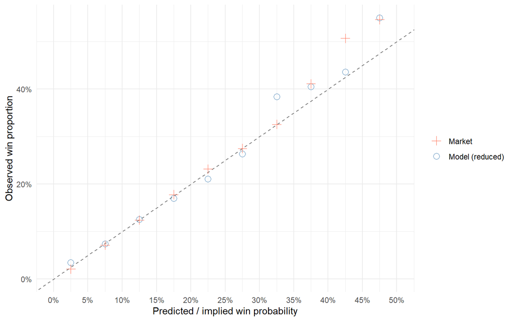

Figure 17: Figure 7 (Owen 2019, §3.3, replicated on AW test data): observed win proportion vs predicted / implied win probability, binned in 5-point intervals over [0, 0.50]. Circles = reduced model out-of-sample; plus signs = market. Reference line y = x is perfect calibration.

## 4.5 Out-of-sample evaluation: P1 and P2 scoring rules

Owen’s Figure 8 plots two scoring rules against a probability threshold. One caveat to flag up front before any comparison with Owen’s headline numbers: Owen reports P1 and P2 *in-sample* on the training set as a goodness-of-fit diagnostic, while the values we compute below are *out-of-sample* on the held-out test races. Out-of-sample scores will, on average, trail in-sample scores for any non-trivial fit, so reading directly from his quoted P1 / P2 magnitudes to ours overstates any apparent gap. We return to this in Section 5.

For each threshold $t$, we take the subset of runner-rows whose respective probability exceeds $t$, then compute

- **P1** (geometric mean of probability assigned to winners):
  $$P_1(t) = \exp\!\left(\frac{1}{N_w}\sum_{i \in \text{winners}} \log p_{ij}\right).$$
- **P2** (geometric mean of per-row Bernoulli likelihood):
  $$P_2(t) = \exp\!\left(\frac{1}{N}\!\left[\sum_{\text{winners}}\log p + \sum_{\text{losers}} \log(1 - p)\right]\right).$$

P1 rewards high probability on actual winners; P2 also penalises high probability on losers (proper scoring rule). Higher is better for both.

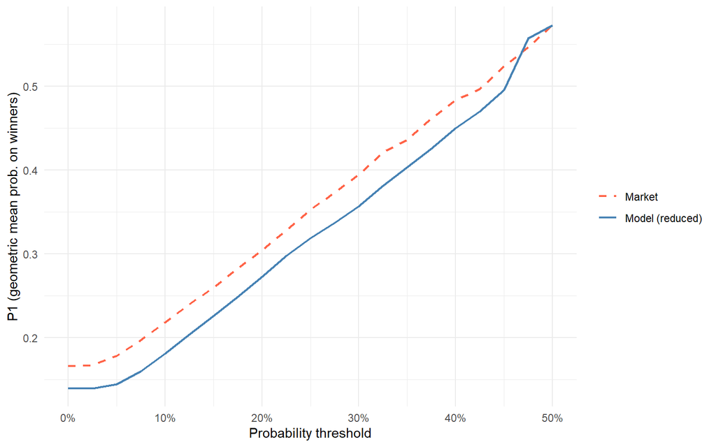

Figure 18: Figure 8(a) (Owen 2019, §3.3, replicated on AW test data): P1 against probability threshold for the reduced model (solid) and the market (dashed). Higher = more probability concentrated on eventual winners.

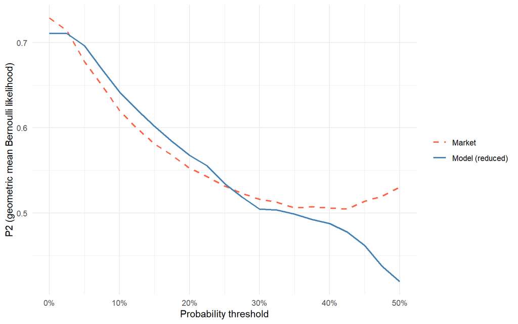

Figure 19: Figure 8(b) (Owen 2019, §3.3, replicated on AW test data): P2 against probability threshold. Higher = better calibration plus better discrimination (proper scoring rule).

Table 11: Subset sizes and scoring values at each threshold for the reduced model and the market. As the threshold rises, fewer rows qualify; P1 and P2 estimates become noisier.

| threshold | n_Model (reduced) | n_Market | n_winners_Model (reduced) | n_winners_Market | P1_Model (reduced) | P1_Market | P2_Model (reduced) | P2_Market |
| --- | --- | --- | --- | --- | --- | --- | --- | --- |
| 0.000 | 18793 | 18793 | 2224 | 2224 | 0.1395 | 0.1663 | 0.7110 | 0.7287 |
| 0.025 | 18734 | 17494 | 2222 | 2215 | 0.1397 | 0.1677 | 0.7105 | 0.7142 |
| 0.050 | 16935 | 14039 | 2159 | 2124 | 0.1448 | 0.1785 | 0.6964 | 0.6776 |
| 0.075 | 12985 | 11101 | 1919 | 1944 | 0.1603 | 0.1972 | 0.6685 | 0.6497 |
| 0.100 | 9351 | 8438 | 1598 | 1724 | 0.1811 | 0.2182 | 0.6420 | 0.6203 |
| 0.125 | 6624 | 6555 | 1275 | 1506 | 0.2043 | 0.2401 | 0.6211 | 0.5993 |
| 0.150 | 4709 | 5158 | 1014 | 1316 | 0.2263 | 0.2600 | 0.6016 | 0.5809 |
| 0.175 | 3284 | 4006 | 786 | 1116 | 0.2491 | 0.2830 | 0.5839 | 0.5675 |
| 0.200 | 2249 | 3099 | 596 | 950 | 0.2730 | 0.3043 | 0.5676 | 0.5527 |
| 0.225 | 1540 | 2355 | 444 | 782 | 0.2976 | 0.3284 | 0.5553 | 0.5425 |
| 0.250 | 1033 | 1766 | 340 | 641 | 0.3190 | 0.3529 | 0.5342 | 0.5315 |
| 0.275 | 725 | 1381 | 264 | 541 | 0.3370 | 0.3731 | 0.5186 | 0.5229 |
| 0.300 | 490 | 1061 | 197 | 447 | 0.3565 | 0.3944 | 0.5045 | 0.5163 |
| 0.325 | 323 | 775 | 132 | 350 | 0.3808 | 0.4208 | 0.5035 | 0.5126 |
| 0.350 | 214 | 616 | 91 | 302 | 0.4035 | 0.4361 | 0.4989 | 0.5057 |
| 0.375 | 139 | 451 | 62 | 232 | 0.4255 | 0.4617 | 0.4924 | 0.5075 |
| 0.400 | 88 | 329 | 40 | 184 | 0.4500 | 0.4831 | 0.4876 | 0.5059 |
| 0.425 | 58 | 263 | 28 | 158 | 0.4697 | 0.4964 | 0.4778 | 0.5047 |
| 0.450 | 33 | 185 | 16 | 111 | 0.4952 | 0.5238 | 0.4618 | 0.5136 |
| 0.475 | 17 | 129 | 6 | 83 | 0.5570 | 0.5463 | 0.4372 | 0.5198 |
| 0.500 | 13 | 88 | 5 | 58 | 0.5725 | 0.5729 | 0.4193 | 0.5304 |

## 4.6 Discussion

The coefficient picture lands close to where Owen’s recipe predicts. Signs agree across the great majority of retained features, and the features Owen drops as non-significant — `position3` and three of the four tack indicators — drop out at p < 0.05 in his fit. On AW some of those terms (`blinkers`, `tonguetie`, the `position3` factor) do reach significance in our reduced fit; on roughly ten times as many training races, smaller true effects become statistically detectable, so this is a sample-size phenomenon rather than a substantive AW / Turf difference. Two more substantive magnitude differences are worth singling out from Table 9. First, the `gelding` coefficient is roughly half Owen’s (+0.28 vs +0.55). The AW Class 2–5 population is 65% geldings — more than the broader Turf flat — so the contrast between geldings and the non-gelding reference is mechanically compressed on AW, and the coefficient with it. Second, the strike-rate finding flagged in Section 4: after the suspected percent-vs-proportion scale correction, AW trainerSR matches Owen’s almost exactly while AW sireSR is about half. The trainer effect appears to be a stable feature of British handicap racing irrespective of surface; the sire effect is plausibly weaker on AW because horses are older and more of their ability is visible in their own record rather than inherited.

The most plausible reading is that the conditional-logit specification — Owen’s, ours, or any thirteen-feature variant — is asked to compete against a starting price that already aggregates much richer information. The SP encodes weight carried, draw, going, distance suitability, jockey, recent workout form, course form, and the collective judgment of informed money. Our thirteen features capture none of that directly. The surprise is not that the model trails the market; it would be remarkable if it did not. What is genuinely interesting in Owen’s paper is that on a small test set (264 bets, 512 races) his model nonetheless generated a positive ROI of the order of 20%. With a sample that size, the sampling distribution of ROI is wide enough that the 90% CI plausibly includes zero, and Owen is careful to hedge accordingly. Our headline ROI is materially negative across 1,713 bets and 2,224 races, with CIs comfortably below zero — a more confident *null* on a much larger sample, rather than a contradiction of a confident *positive*.

Paper 2 picks this up with three specific extensions to the predictor set, all of which the database supplies but neither this paper nor Owen’s uses. **Draw** (stall number) is known to matter on AW and varies with course and distance — it is a horse-race pair feature and belongs in the next specification. **Weight carried** (or each horse’s deviation from the race’s weight range) is a direct readout of the handicapper’s assessment of relative ability within the race, structurally the most natural predictor for a handicap and absent from Owen’s feature list. **Going** and **race class** become available as race-level features through the interaction-with-horse-level trick saved for the paper 2 appendix. The same paper also moves to the exploded conditional logit, so the full finishing order contributes to the fit. Paper 3 then leaves conditional logit behind for a Plackett–Luce R² tree.

# 5 Future predictive performance

Owen’s §3.4 deploys the Table 3 reduced model to the held-out test set and evaluates a unit-stake betting strategy as a forward-looking test of the model’s edge against the market. We do the same on the AW test races (the 30% chronological hold-out after 2012-12-30: 2,224 races, 18,793 runner-rows).

Given the scoring picture established in Section 4 — the model trails the market on both P1 and P2 across most of the threshold range — we approach this analysis with low expectations. A model whose fitted probabilities sit below the market’s on actual winners will not, in general, identify positive-EV bets against market odds. The analysis below confirms this.

## 5.1 Market probability construction

For each test race $k$, the over-round-adjusted market-implied win probability of horse $j$ is constructed from the starting price by renormalising the raw implied probabilities to sum to one over the runners in that race:

$$P^{\text{mkt}}_{jk} \;=\;
\frac{1 / \text{SP}_{jk}}{\sum_{m \in \text{race}_k} 1 / \text{SP}_{m}},$$

where $\text{SP}_{jk}$ is the runner’s starting price in decimal odds. Runners with missing SP are excluded from the bet-selection step (their `market_prob` is NA).

The model/market probability ratio is then $\text{ratio}_{jk} = \hat{P}_{jk} / P^{\text{mkt}}_{jk}$: ratios above 1 are runners the model rates higher than the market; ratios below 1 are runners the model rates lower.

## 5.2 Backtest at Owen’s thresholds

Owen’s bet-selection rule places a unit stake on horse $j$ in race $k$ when both of the following hold:

$$\hat{P}_{jk} > 0.15 \qquad\text{and}\qquad
\text{ratio}_{jk} > 1.3.$$

This rule can qualify more than one horse in a race; Owen does not specify whether he backs one qualifier or all of them, and we back all (the multi-bet rule).[^3]

On Owen’s Turf test set this rule places 264 bets and returns +54 units, an ROI of approximately +20.5%. Applied to our AW test set with the reduced model fit, the same rule gives:

Table 12: AW reduced model: betting backtest on the held-out test races at Owen’s exact thresholds.

| Prob threshold | Ratio threshold | Bets | Wins | Gross return | Profit | ROI |
| --- | --- | --- | --- | --- | --- | --- |
| 0.15 | 1.3 | 1713 | 174 | 1230.46 | -482.54 | -28.2% |

The headline AW ROI is **-28.2%** on 1,713 bets, against Owen’s reported +20.5% on 264 bets. The gap is exactly the picture the scoring-rule plots in Figure 18 and Figure 19 predict: a model that assigns less probability to winners than the market does will not, on average, identify market-beating bets at any sensible threshold.

## 5.3 ROI across ratio thresholds

To check whether the headline result above is sensitive to the exact 1.3 ratio threshold Owen uses, we sweep the ratio threshold $\tau$ from 0.9 to 2.0 in steps of 0.05, hold the model-probability threshold fixed at 0.13 (chosen on the AW scoring picture rather than copied from Owen’s 0.15), and compute point ROI plus a 90% bootstrap confidence interval at each $\tau$. The bootstrap resamples **races** (not runner-rows) with replacement, $B = 2000$ draws, seed fixed at 42 for reproducibility. Race-level resampling preserves the one-winner-per-race structure of the choice sets.

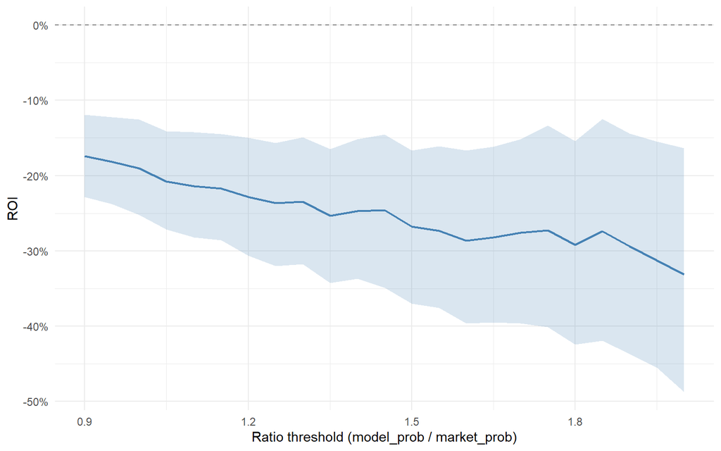

Figure 20: ROI vs ratio threshold on the AW test set, with 90% bootstrap CI (shaded). Model-probability filter held at 0.13. Dashed horizontal line at zero marks break-even.

Table 13: ROI sweep over ratio thresholds with 90% bootstrap CIs (B = 2000, race-level resampling, seed 42).

| Ratio threshold | Bets | Wins | ROI | 90% CI low | 90% CI high |
| --- | --- | --- | --- | --- | --- |
| 0.90 | 4047 | 575 | -17.4% | -22.8% | -11.9% |
| 0.95 | 3778 | 509 | -18.2% | -23.8% | -12.2% |
| 1.00 | 3517 | 449 | -19.0% | -25.2% | -12.6% |
| 1.05 | 3293 | 394 | -20.8% | -27.1% | -14.1% |
| 1.10 | 3093 | 353 | -21.4% | -28.2% | -14.2% |
| 1.15 | 2871 | 313 | -21.7% | -28.6% | -14.5% |
| 1.20 | 2663 | 273 | -22.9% | -30.7% | -15.0% |
| 1.25 | 2495 | 246 | -23.6% | -32.0% | -15.7% |
| 1.30 | 2317 | 222 | -23.4% | -31.8% | -14.9% |
| 1.35 | 2167 | 195 | -25.3% | -34.3% | -16.5% |
| 1.40 | 2009 | 178 | -24.7% | -33.7% | -15.2% |
| 1.45 | 1884 | 163 | -24.6% | -34.9% | -14.5% |
| 1.50 | 1756 | 142 | -26.7% | -37.0% | -16.6% |
| 1.55 | 1628 | 126 | -27.3% | -37.6% | -16.1% |
| 1.60 | 1528 | 114 | -28.6% | -39.7% | -16.7% |
| 1.65 | 1432 | 105 | -28.2% | -39.5% | -16.1% |
| 1.70 | 1328 | 96 | -27.6% | -39.7% | -15.1% |
| 1.75 | 1228 | 86 | -27.3% | -40.1% | -13.4% |
| 1.80 | 1158 | 77 | -29.2% | -42.5% | -15.4% |
| 1.85 | 1096 | 73 | -27.4% | -42.0% | -12.5% |
| 1.90 | 1025 | 65 | -29.4% | -43.7% | -14.4% |
| 1.95 | 954 | 56 | -31.3% | -45.5% | -15.5% |
| 2.00 | 906 | 50 | -33.1% | -48.8% | -16.3% |

## 5.4 Owen’s training-set vs our test-set scoring numbers

A caveat worth flagging on direct comparison with Owen’s headline numbers. Owen’s reported P1 / P2 values (P1_model = 0.120, P1_market = 0.136, P2_model = 0.860, P2_market = 0.831 in his §3.3) are computed on the **training** set as goodness-of-fit diagnostics. Our P1 / P2 in Section 4 are evaluated on the held- out **test** set as out-of-sample forecasts. The two sets of numbers are not directly comparable — out-of-sample scores will typically trail in-sample for any non-trivial fit.

The §3.4 ROI comparison above, however, is like-for-like: Owen’s +20.5% and our AW ROI here are both evaluated out-of-sample on the respective held-out test races.

## 5.5 Closing remark

The AW backtest confirms the negative result the scoring rules already implied. The interesting question is not *whether* the model trails the market — given thirteen features against an SP that aggregates weight, draw, jockey, going, distance form, recent workouts and informed money, that direction is set in advance — but *what is missing from the model* that lets the market lead. Each of the candidates listed in Section 4 (draw, weight carried, going, race class) is a property of horse-race pairs that the SP already prices, and each is absent from Owen’s specification and ours. Paper 2 adds them, and reframes the comparison as a test of how much of the market’s edge is recoverable when the feature set is widened to overlap meaningfully with the information set that the SP itself sits on. That paper also moves to the exploded conditional logit, so the full finishing order — not just the win — contributes to the fit. Whether either change is enough to close the gap is the question paper 2 will answer.

# Acknowledgments

I have been interested in modelling horse racing since first acquiring the Smartform database more than a decade ago. The project has been picked up and put down many times, the obstacle almost always being the gap between an idea and a running implementation. What is different now is that working alongside Claude Code (Anthropic’s coding agent), with web-based Claude as a research companion, has compressed that gap dramatically. I am grateful to my brother, Michael Gillen, for the suggestion to build the model on All-Weather races — the foundation of the scope choices set out in Section 2. The design choices — dataset, scope, model, comparison, editorial line — are mine. The implementation, the bulk of the draft prose, and a great deal of the verification were Claude Code’s, under my direction; every output was reviewed and edited before it reached the paper. I do not yet know what general lessons this experiment points to about the value of human–AI collaboration in applied statistics. That uncertainty is part of why I am doing the work, and these papers are partly a record of that experiment.

# References

Owen, Alun. 2019. “Statistical Models of Horse Racing Outcomes Using R.” *MathSport International 2019 Conference Proceedings* (Athens, Greece).

## 6 Appendix: From binary logistic regression to the conditional logit

This appendix derives the conditional-logit model used in Section 4 from the more familiar binary logistic regression, by way of the multinomial case. The aim is exposition, not novelty: all of this material is standard, but writing it out in one place clarifies the assumptions the headline AW model rests on, and the limitations of the simpler models it builds on.

## 6.1 Binary logistic regression

In the context of horse racing, this type of regression models the probability that a particular horse $i$ wins a particular race, given that horse’s features $x_{i1}, \ldots, x_{ik}$. The model assumes
$$p_i = \frac{e^{z_i}}{1+e^{z_i}}$$
where
$$z_i = \beta_0 + \sum_{l=1}^k \beta_l x_{il}.$$
It follows that the odds are
$$\frac{p_i}{1-p_i} = e^{z_i},$$
and hence the log-odds are linear in the features:
$$\log\frac{p_i}{1-p_i} = \beta_0 + \sum_{l=1}^k \beta_l x_{il}.$$

Let the index $i$ run over each horse in each race, with $y_i = 1$ if that horse wins its race and $0$ otherwise. Given a set of races, the likelihood of the observed outcomes is
$$\prod_{i=1}^n p_i^{y_i}(1-p_i)^{1-y_i},$$
and the log-likelihood is
$$\sum_{i=1}^n \left( y_i \log p_i + (1-y_i)\log(1-p_i) \right).$$
Substituting for $p_i$ gives
$$\sum_{i=1}^n \left( y_i z_i - \log\left(1+e^{z_i}\right) \right).$$
This is a function of the coefficients to be maximised (or, equivalently, its negative minimised). Because its Hessian is negative semidefinite, the function is concave, so any local maximum is also the global maximum.

**NoteRemark (empirical logit)**

The linearity of the log-odds,
$$\log\frac{p_i}{1-p_i} = \beta_0+\sum_{l=1}^{k}\beta_l x_{il},$$
suggests a more direct route: if the log-odds could be observed, it could simply be regressed on the predictors. With grouped data — many runners sharing the same feature values, so that a win proportion $\hat{p}$ can be formed within each group — this is precisely Berkson’s empirical-logit approach, which regresses
$$\log\frac{\hat{p}}{1-\hat{p}}$$
on the predictors by weighted least squares. As the group sizes grow, $\hat{p} \to p$ and the estimator becomes asymptotically equivalent to maximum likelihood. It breaks down, however, for ungrouped binary data, where each observation is a single win or loss: then $\hat{p}$ is $0$ or $1$, the empirical log-odds is $\pm\infty$, and the regression is undefined (a continuity correction patches this but introduces bias). Racing data is of exactly this ungrouped kind — one row per horse per race — so the empirical-logit shortcut is unavailable, and maximum likelihood is the appropriate tool.

A textbook reference for the binary case is James et al. (2021), §4.3.

There is a deeper limitation of the binary model in the racing context, beyond the empirical-logit shortcut. Binary logistic regression treats each horse-race row as an independent Bernoulli trial: the probability that horse $i$ wins depends only on its own features, with nothing in the model linking the predictions of different horses in the same race. In particular, the fitted $p_i$ across the horses in a single race need not sum to one — but exactly one horse wins each race, so they should. The fitted probabilities are coherent as marginal estimates of each horse’s chance, but they ignore the within-race competition entirely. The multinomial logit below addresses part of this problem; the conditional logit, the rest.

## 6.2 Multinomial logistic regression

These models estimate the probability $p_{ij}$ that an individual $i$ chooses alternative $j$ from a set of $J$ mutually exclusive alternatives. The probabilities are parametrised as
$$p_{ij} = \frac{e^{z_{ij}}}{\sum_{m=1}^J e^{z_{im}}}$$
— the softmax — where
$$z_{ij} = \beta_{0j} + \sum_{l=1}^{k} \beta_{lj} x_{il}.$$
The term *softmax* is used because this function is a smooth approximation to *argmax*: where argmax returns a one-hot vector, softmax spreads the unit mass across all $J$ alternatives, with the largest $z_{ij}$ dominating as the scores spread apart.

Here the index $l$ runs over features of the individual choosing between the alternatives. For example, a person choosing between alternative modes of transport may have features such as income, age, and so on. $x_{il}$ is the $l$-th feature of individual $i$ and $\beta_{lj}$ is the coefficient that links feature $l$ to alternative $j$. The subscript $0$ on $\beta_{0j}$ denotes the intercept for alternative $j$, not a coefficient for some zeroth individual: it captures the baseline log-odds of choosing alternative $j$ over the reference when all features are zero, and is well-defined precisely because $j$ indexes a fixed, labelled set of alternatives. This formulation is called *individual-specific*.

It is overparameterised, however: adding any constant vector $\mathbf{c}$ to every $\boldsymbol{\beta}_j$ multiplies every term in the softmax by $e^{\mathbf{c}^\top\mathbf{x}_i}$, which cancels between numerator and denominator, leaving all probabilities unchanged. To resolve this, we fix alternative $J$ as the reference and set $\boldsymbol{\beta}_J = \mathbf{0}$, i.e., the set of individual-specific coefficients for alternative $J$, giving
$$p_{ij} = \frac{e^{z_{ij}}}{1+\sum_{m=1}^{J-1} e^{z_{im}}}$$
for $j < J$ and
$$p_{iJ} = \frac{1}{1+\sum_{m=1}^{J-1} e^{z_{im}}}.$$

It follows that the log-odds of alternative $j$ relative to the reference alternative $J$ are
$$\log\frac{p_{ij}}{p_{iJ}}
= \log\frac{e^{z_{ij}}}{1+\sum_{m=1}^{J-1}e^{z_{im}}}
- \log\frac{1}{1+\sum_{m=1}^{J-1}e^{z_{im}}}
= z_{ij},$$
which is linear in the features:
$$\log\frac{p_{ij}}{p_{iJ}}
= \beta_{0j} + \sum_{l=1}^k \beta_{lj} x_{il}.$$

Let the index $i$ run over individuals and $j$ over alternatives, with $y_{ij} = 1$ if individual $i$ chooses alternative $j$ and $0$ otherwise. Given a set of observed choices, the likelihood of the observed outcomes is
$$\prod_{i=1}^n \prod_{j=1}^J p_{ij}^{y_{ij}},$$
and the log-likelihood is
$$\sum_{i=1}^n \sum_{j=1}^J y_{ij} \log p_{ij}.$$
Substituting for $p_{ij}$ gives
$$\sum_{i=1}^n \left(
\sum_{j=1}^{J-1} y_{ij} z_{ij}
- \log\left(1+\sum_{m=1}^{J-1}e^{z_{im}}\right)
\right).$$
This is a function of the coefficients to be maximised. As in the binary case, the log-likelihood is concave, so any local maximum is also the global maximum. The multinomial extension is due to McFadden (1974).

The multinomial model is awkward for horse racing in a different way than the binary model was. Its predictors $x_{il}$ are indexed by the individual $i$ and the feature $l$, with no index for the alternative $j$. In the racing analogue — where $i$ is a race and $j$ is a horse — this implies that every feature of interest is a property of the race, the same for every horse in it. But the features that matter most (speed figure, weight carried, days since last race) are properties of horse–race pairs, varying across horses within a race. The multinomial logit has nowhere to put such features. The conditional logit below addresses exactly this by carrying the alternative index into the predictors.

## 6.3 Conditional logit

Multinomial logistic regression assumes that the features $x_{il}$ describe the individual and do not vary across alternatives. In horse racing this is inadequate: the most natural features — speed figures, weight carried, days since last race — are properties of a horse–race pair, not of the horse alone. A feature such as speed figure takes a different value for each horse in each race, so it carries an alternative index: $x_{ilj}$ is the $l$-th feature of individual $i$ for alternative $j$. This is called an *alternative-specific* formulation.

To accommodate this, the linear predictor becomes
$$z_{ij} = \sum_{l=1}^k \beta_l x_{ilj},$$
where crucially the coefficients $\beta_l$ no longer carry a $j$ index: since the features already vary across alternatives, a single coefficient suffices to capture the effect of each feature. Note also that alternative-specific intercepts $\beta_{0j}$ are not identified in this formulation and are dropped.

The softmax parametrisation, log-odds, likelihood, and log-likelihood are then identical to the multinomial case — only the definition of $z_{ij}$ changes. The conditional-logit model is the workhorse fitted in Section 4.

### References for this appendix

- James, G., Witten, D., Hastie, T., & Tibshirani, R. (2021). *An Introduction to Statistical Learning: With Applications in R* (2nd ed.). Springer.
- McFadden, D. (1974). Conditional Logit Analysis of Qualitative Choice Behavior. In P. Zarembka (Ed.), *Frontiers in Econometrics* (pp. 105–142). Academic Press.

## 7 Appendix: Software and reproducibility

All work in this paper is in R (R Core Team, 2024) and was built up under the following stack:

- **[tidyverse](https://www.tidyverse.org/)** for data manipulation, iteration and plotting (`dplyr`, `tidyr`, `purrr`, `ggplot2`, `stringr`, `forcats`, `lubridate`, `readr`). A *tibble* is the tidyverse’s tidy data frame — strict rules about column types and printing, otherwise behaves like a `data.frame`.
- **[{targets}](https://docs.ropensci.org/targets/)** and **[{tarchetypes}](https://docs.ropensci.org/tarchetypes/)** for the pipeline. Each step in the data → features → model → render chain is a `tar_target()`; intermediate results are cached on disk, and only stale steps re-run when the upstream changes.
- **[{mlogit}](https://cran.r-project.org/package=mlogit)** for the conditional-logit fits in Section 4.
- **[{DBI}](https://dbi.r-dbi.org/)** and **[{RMariaDB}](https://rmariadb.r-dbi.org/)** for reading from the Smartform MySQL database.
- **[{renv}](https://rstudio.github.io/renv/)** for pinning package versions; the `renv.lock` file accompanying the project records the exact versions used.
- **[Quarto](https://quarto.org/)** for typesetting the document you are reading. The master `index.qmd` and section partials render to a single HTML article via `quarto::quarto_render()`, driven from the `{targets}` pipeline.

The full source — pipeline, SQL, feature builders, paper partials — is held in a single project tree. Running `targets::tar_make()` from the project root rebuilds every cached intermediate that is stale and re-renders the paper.

### Reference for this appendix

- R Core Team (2024). *R: A Language and Environment for Statistical Computing*. R Foundation for Statistical Computing, Vienna, Austria. https://www.R-project.org/.

## Footnotes

[^1]: This revision adds a clarification of Owen’s betting-selection rule: it can qualify more than one horse per race, and this paper backs all qualifiers.
[^2]: A *tibble* is the tidyverse’s tidy data frame — strict about column types and printing, otherwise behaves like a `data.frame`. See Section 7 for the full software stack.
[^3]: From paper 2a onwards we adopt the single-bet variant — backing only the highest-model-probability qualifier per race — as the primary, more realistic rule.